# Stat5405 Homework 1

Author

Giovanni Lunetta

Published

September 8, 2023

## Due: Sun. Sep. 10 2023 at 11:59 pm - submit on HuskyCT

1. Use the trees data in the R package datasets. Explain what you see when you use the boxplot() function in the following ways:

```r
data(trees)
str(trees)
```

```
'data.frame':   31 obs. of  3 variables:
 $ Girth : num  8.3 8.6 8.8 10.5 10.7 10.8 11 11 11.1 11.2 ...
 $ Height: num  70 65 63 72 81 83 66 75 80 75 ...
 $ Volume: num  10.3 10.3 10.2 16.4 18.8 19.7 15.6 18.2 22.6 19.9 ...
```

1. boxplot(Volume, varwidth = TRUE)

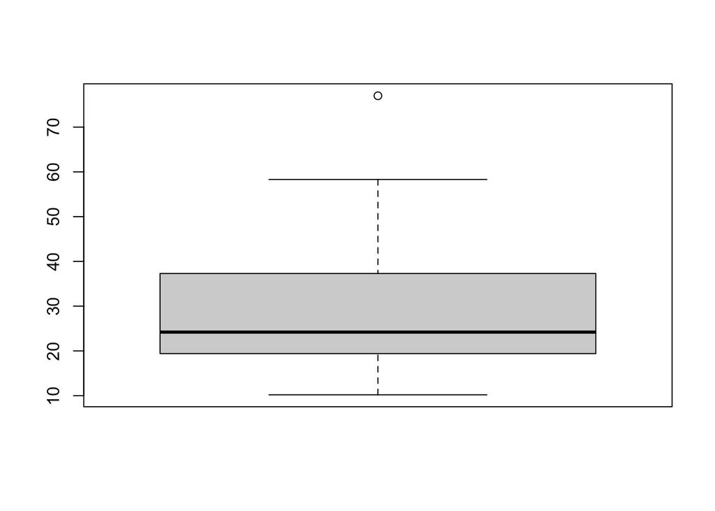

```r
boxplot(trees$Volume, varwidth = TRUE)
```

**This boxplot shows us the distribution of the Volume of the trees in the dataset. We see that Volume is heavily skewed to the right with an outlier above 70. We see that the median sits around 25. We can estimate that the IQR is about 18 from Q1(20) and Q3 (38). Overall, most of the trees have a volume between 20 and 38.**

2. boxplot(Girth, notch = TRUE)

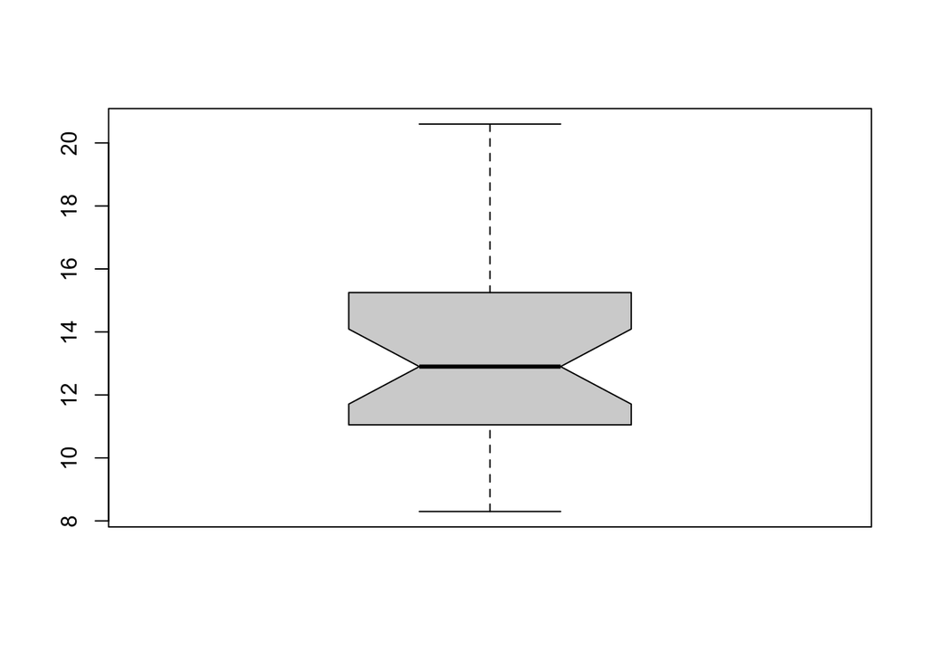

```r
boxplot(trees$Girth, notch = TRUE)
```

2. Use the trees data in the R package datasets.
1. Use the gglot2 package to construct a boxplot of Volume, in black with a horizontal orientation rather than the default vertical gray boxplot.

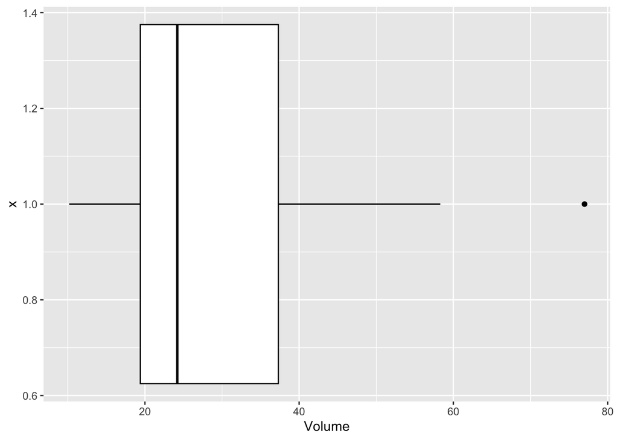

```r
library(ggplot2)

ggplot(trees, aes(x=1, y=Volume)) +
  geom_boxplot(color="black") +
  coord_flip()
```

2. Discuss whether you can assume that Volume follows a normal distribution, and if not, in what way(s) the data departs from normality. Use the normal Q-Q plot, as well as the Shapiro-Wilk and chi-square goodness of fit tests for normality.

**The boxplot shows us that the data is not normally distributed. We see that the data is skewed to the right.**

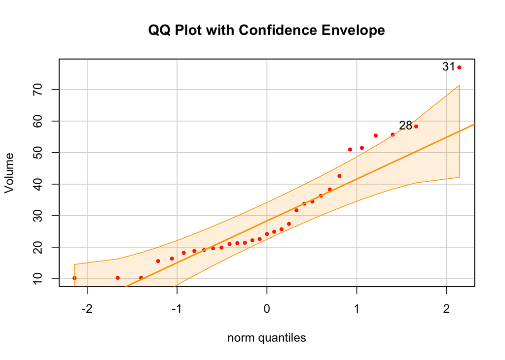

```
[1] 31 28
```

```r
library(car)
# QQ plot with confidence bands
qqPlot(trees$Volume, main="QQ Plot with Confidence Envelope",
       ylab="Volume", cex=0.6, pch=19, col="red", col.lines="orange")
```

**The qqplot shows us that the data is not normally distributed. We see that the data is skewed to the right. We also see that there are multiple points that lie outside of the confidence bands.**

```r
shapiro.test(trees$Volume)
```

```
    Shapiro-Wilk normality test

data:  trees$Volume
W = 0.88757, p-value = 0.003579
```

**The Shapiro-Wilk test shows us that the data is not normally distributed. We see that the p-value is less than 0.05.**

```r
library(nortest)

pearson.test(trees$Volume)
```

```
    Pearson chi-square normality test

data:  trees$Volume
P = 15.194, p-value = 0.009567
```

**The chi-square test shows us that the data is not normally distributed. We see that the p-value is less than 0.05.**

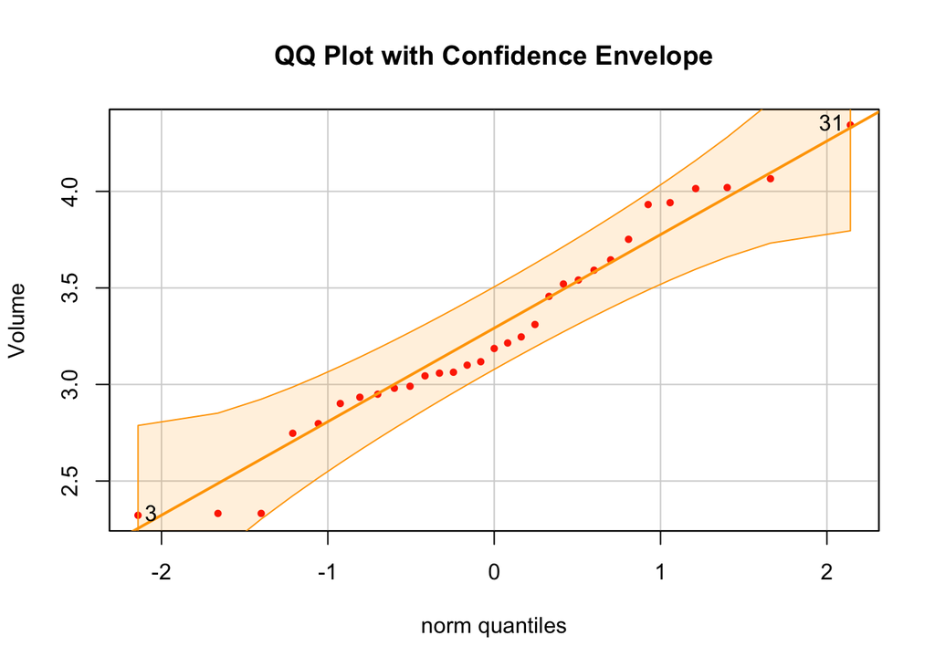

```
[1] 31  3
```

```r
qqPlot(log(trees$Volume), main="QQ Plot with Confidence Envelope",
       ylab="Volume", cex=0.6, pch=19, col="red", col.lines="orange")
```

```r
shap <- shapiro.test(log(trees$Volume))
print(shap)
```

```
    Shapiro-Wilk normality test

data:  log(trees$Volume)
W = 0.96427, p-value = 0.3766
```

```r
chi <- pearson.test(log(trees$Volume))
print(chi)
```

```
    Pearson chi-square normality test

data:  log(trees$Volume)
P = 9, p-value = 0.1091
```

**It is important to mention though, when we take the log of our data, it does follow a normal distrbution. We see this from the QQ-plot and also both statistical tests are not significant at alpha=0.05.**

3. Use the mtcars data from the R package datasets.

```r
data(mtcars)
str(mtcars)
```

```
'data.frame':   32 obs. of  11 variables:
 $ mpg : num  21 21 22.8 21.4 18.7 18.1 14.3 24.4 22.8 19.2 ...
 $ cyl : num  6 6 4 6 8 6 8 4 4 6 ...
 $ disp: num  160 160 108 258 360 ...
 $ hp  : num  110 110 93 110 175 105 245 62 95 123 ...
 $ drat: num  3.9 3.9 3.85 3.08 3.15 2.76 3.21 3.69 3.92 3.92 ...
 $ wt  : num  2.62 2.88 2.32 3.21 3.44 ...
 $ qsec: num  16.5 17 18.6 19.4 17 ...
 $ vs  : num  0 0 1 1 0 1 0 1 1 1 ...
 $ am  : num  1 1 1 0 0 0 0 0 0 0 ...
 $ gear: num  4 4 4 3 3 3 3 4 4 4 ...
 $ carb: num  4 4 1 1 2 1 4 2 2 4 ...
```

1. Create a matrix scatterplot for the variables in the mtcars data. With which variables is mpg highly associated?

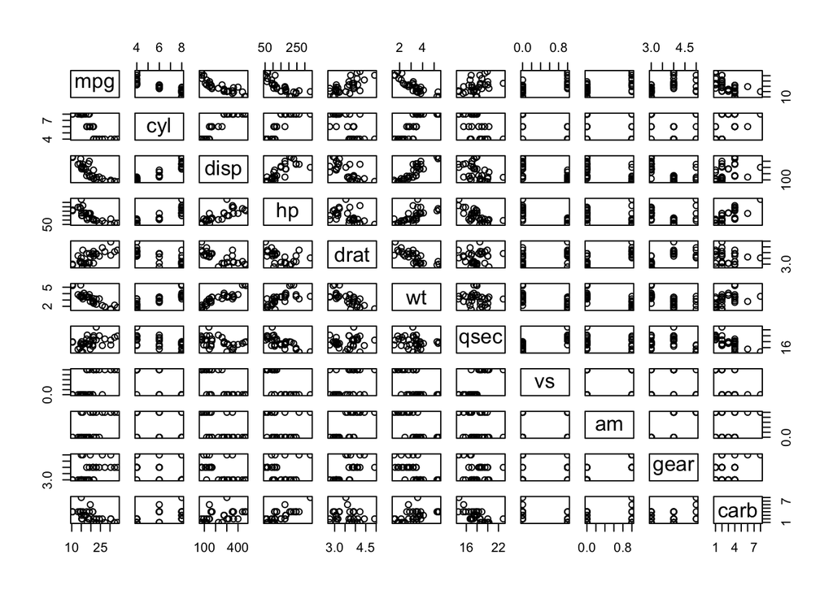

```r
pairs(mtcars)
```

**We see that mpg is highly associated with cyl, disp, hp, drat, and wt.**

2. Which pair of variables in the mtcars data has the highest correlation? (Hint: use the cor() function. )

```r
# Compute the correlation matrix
cor_matrix <- cor(mtcars)
cor_matrix
```

```
            mpg        cyl       disp         hp        drat         wt
mpg   1.0000000 -0.8521620 -0.8475514 -0.7761684  0.68117191 -0.8676594
cyl  -0.8521620  1.0000000  0.9020329  0.8324475 -0.69993811  0.7824958
disp -0.8475514  0.9020329  1.0000000  0.7909486 -0.71021393  0.8879799
hp   -0.7761684  0.8324475  0.7909486  1.0000000 -0.44875912  0.6587479
drat  0.6811719 -0.6999381 -0.7102139 -0.4487591  1.00000000 -0.7124406
wt   -0.8676594  0.7824958  0.8879799  0.6587479 -0.71244065  1.0000000
qsec  0.4186840 -0.5912421 -0.4336979 -0.7082234  0.09120476 -0.1747159
vs    0.6640389 -0.8108118 -0.7104159 -0.7230967  0.44027846 -0.5549157
am    0.5998324 -0.5226070 -0.5912270 -0.2432043  0.71271113 -0.6924953
gear  0.4802848 -0.4926866 -0.5555692 -0.1257043  0.69961013 -0.5832870
carb -0.5509251  0.5269883  0.3949769  0.7498125 -0.09078980  0.4276059
            qsec         vs          am       gear        carb
mpg   0.41868403  0.6640389  0.59983243  0.4802848 -0.55092507
cyl  -0.59124207 -0.8108118 -0.52260705 -0.4926866  0.52698829
disp -0.43369788 -0.7104159 -0.59122704 -0.5555692  0.39497686
hp   -0.70822339 -0.7230967 -0.24320426 -0.1257043  0.74981247
drat  0.09120476  0.4402785  0.71271113  0.6996101 -0.09078980
wt   -0.17471588 -0.5549157 -0.69249526 -0.5832870  0.42760594
qsec  1.00000000  0.7445354 -0.22986086 -0.2126822 -0.65624923
vs    0.74453544  1.0000000  0.16834512  0.2060233 -0.56960714
am   -0.22986086  0.1683451  1.00000000  0.7940588  0.05753435
gear -0.21268223  0.2060233  0.79405876  1.0000000  0.27407284
carb -0.65624923 -0.5696071  0.05753435  0.2740728  1.00000000
```

```r
# Set the diagonal and upper triangle to NA
cor_matrix[lower.tri(cor_matrix, diag = TRUE)] <- NA

# Find the location of the maximum absolute correlation
loc_max <- which(abs(cor_matrix) == max(abs(cor_matrix), na.rm = TRUE), arr.ind = TRUE)

# Extract the variable names for the maximum correlation
var1 <- rownames(cor_matrix)[loc_max[1, 1]]
var2 <- colnames(cor_matrix)[loc_max[1, 2]]

# Extract the maximum correlation value
max_cor <- cor_matrix[loc_max[1, 1], loc_max[1, 2]]

list(variable1 = var1, variable2 = var2, correlation = max_cor)
```

```
$variable1
[1] "cyl"

$variable2
[1] "disp"

$correlation
[1] 0.9020329
```

**We see that the pair of variables cyl and disp has the highest correlation.**

4. Download historical weather data for Indian cities from kaggle. Create your own interesting visualization(s) and discuss.

```r
bangalore <- read.csv("/Users/giovanni-lunetta/uconn_masters/stat5405/hw_1/Temperature_And_Precipitation_Cities_IN/Bangalore_1990_2022_BangaloreCity.csv")
chennai <- read.csv("/Users/giovanni-lunetta/uconn_masters/stat5405/hw_1/Temperature_And_Precipitation_Cities_IN/Chennai_1990_2022_Madras.csv")
delhi <- read.csv("/Users/giovanni-lunetta/uconn_masters/stat5405/hw_1/Temperature_And_Precipitation_Cities_IN/Delhi_NCR_1990_2022_Safdarjung.csv")
lucknow <- read.csv("/Users/giovanni-lunetta/uconn_masters/stat5405/hw_1/Temperature_And_Precipitation_Cities_IN/Lucknow_1990_2022.csv")
mumbai <- read.csv("/Users/giovanni-lunetta/uconn_masters/stat5405/hw_1/Temperature_And_Precipitation_Cities_IN/Bangalore_1990_2022_BangaloreCity.csv")
rajasthan <- read.csv("/Users/giovanni-lunetta/uconn_masters/stat5405/hw_1/Temperature_And_Precipitation_Cities_IN/Rajasthan_1990_2022_Jodhpur.csv")
station <- read.csv("/Users/giovanni-lunetta/uconn_masters/stat5405/hw_1/Temperature_And_Precipitation_Cities_IN/Station_GeoLocation_Longitute_Latitude_Elevation_EPSG_4326.csv")
bhubhneshwar <- read.csv("/Users/giovanni-lunetta/uconn_masters/stat5405/hw_1/Temperature_And_Precipitation_Cities_IN/weather_Bhubhneshwar_1990_2022.csv")
rourkela <- read.csv("/Users/giovanni-lunetta/uconn_masters/stat5405/hw_1/Temperature_And_Precipitation_Cities_IN/weather_Rourkela_2021_2022.csv")
```

```r
# Add a city column to each dataset
bangalore$city <- "Bangalore"
chennai$city <- "Chennai"
delhi$city <- "Delhi"
lucknow$city <- "Lucknow"
mumbai$city <- "Mumbai"
rajasthan$city <- "Rajasthan"

# Combine all datasets
df <- rbind(bangalore, chennai, delhi, lucknow, mumbai, rajasthan)

str(df)
```

```
'data.frame':   71364 obs. of  6 variables:
 $ time: chr  "01-01-1990" "02-01-1990" "03-01-1990" "04-01-1990" ...
 $ tavg: num  22.9 21.7 21 20.8 20.4 20.4 18.8 20 21 21.2 ...
 $ tmin: num  19.1 NA 16.4 NA 14.2 17.1 NA 16.6 15.5 15 ...
 $ tmax: num  28.4 26.5 26.5 27.4 26.1 24.2 20.5 25.1 NA 27.7 ...
 $ prcp: num  NA 0 0 0 0 NA NA 0 0 0 ...
 $ city: chr  "Bangalore" "Bangalore" "Bangalore" "Bangalore" ...
```

```r
# Compute year for the entire dataframe
df$year <- as.numeric(format(as.Date(df$time, format="%d-%m-%Y"), "%Y"))
```

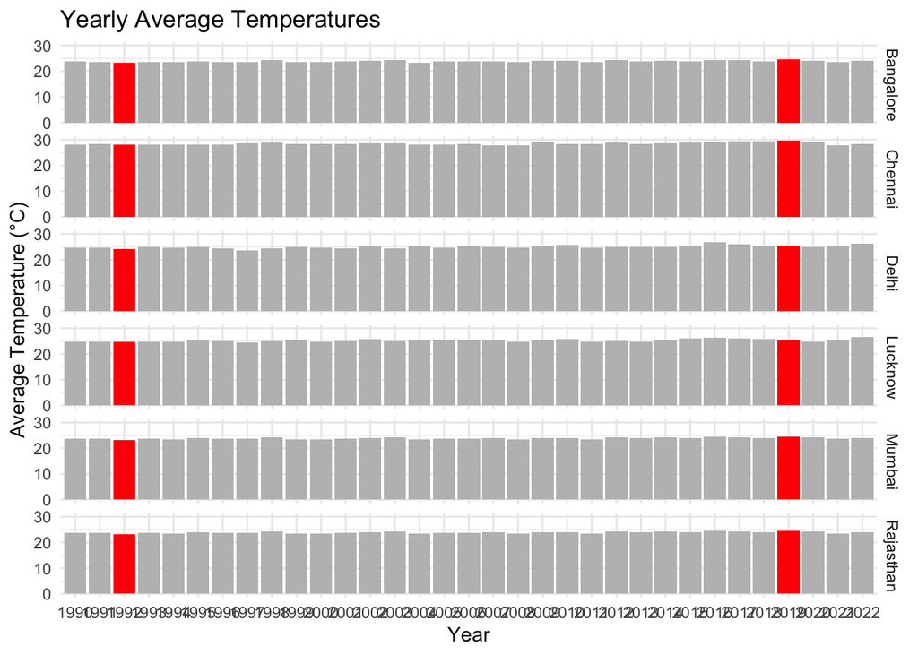

```r
# Compute yearly average temperature for all cities
yearly_avg_all <- aggregate(tavg ~ year + city, data=df, mean, na.rm=TRUE)

# Identify hottest and coldest years for each city
hottest_years <- numeric()
coldest_years <- numeric()

cities <- unique(yearly_avg_all$city)
for (city in cities) {
  city_data <- subset(yearly_avg_all, city == city)
  hottest_years <- c(hottest_years, city_data$year[which.max(city_data$tavg)])
  coldest_years <- c(coldest_years, city_data$year[which.min(city_data$tavg)])
}

# Create bar plot and highlight the hottest and coldest years using facet_grid
ggplot(yearly_avg_all, aes(x=factor(year), y=tavg, fill=(year %in% c(hottest_years, coldest_years)))) +
  geom_bar(stat="identity") +
  scale_fill_manual(values=c("grey", "red"), guide=FALSE) +
  labs(title="Yearly Average Temperatures", x="Year", y="Average Temperature (°C)") +
  facet_grid(city ~ .) +
  theme_minimal()
```

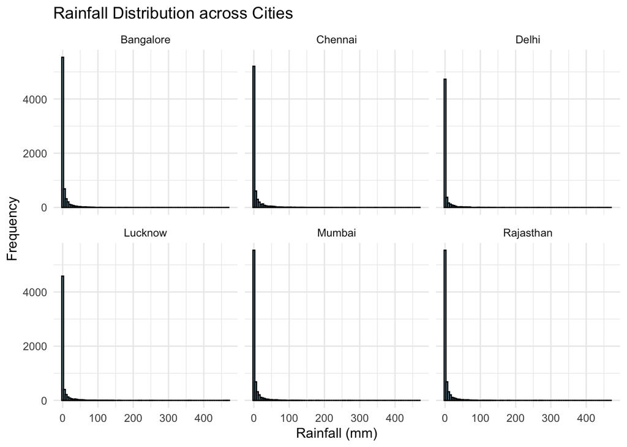

```r
# Histogram of Rainfall Distribution
ggplot(df, aes(x=prcp)) +
  geom_histogram(binwidth=5, fill="skyblue", color="black", alpha=0.7) +
  labs(title="Rainfall Distribution across Cities", x="Rainfall (mm)", y="Frequency") +
  facet_wrap(~city) +
  theme_minimal()
```

**We see that the rainfall distribution is skewed to the right. We see that the majority of the cities have a rainfall between 0 and 50 mm.**

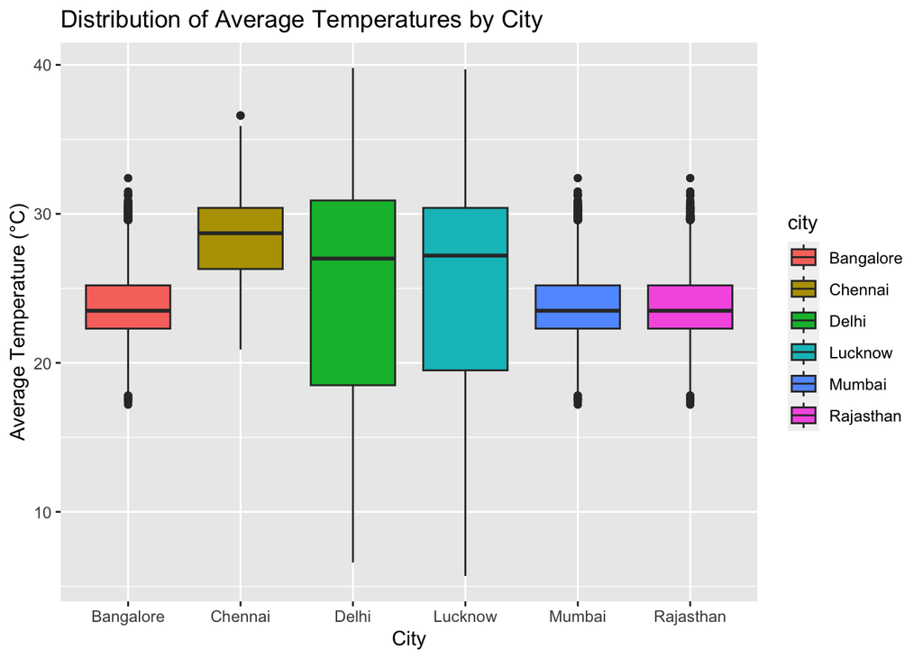

```r
ggplot(df, aes(x = city, y = tavg, fill = city)) +
geom_boxplot() +
labs(title = "Distribution of Average Temperatures by City", x = "City", y = "Average Temperature (°C)")
```

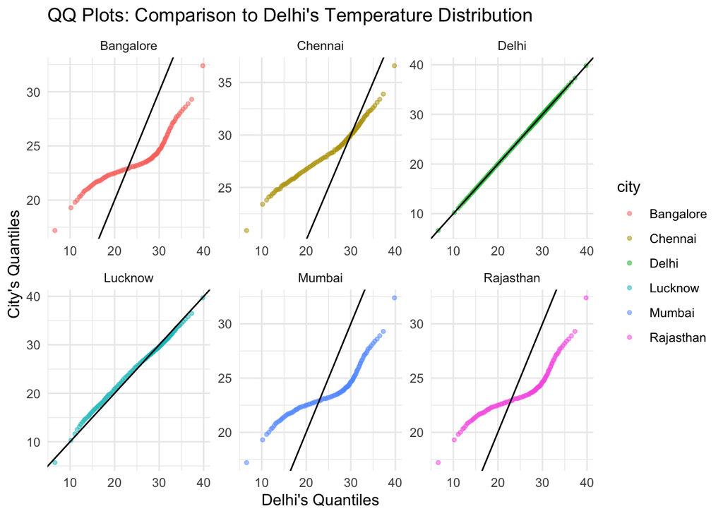

```r
# Create a function to generate sample QQ data for a given city against a reference
get_qq_data <- function(city_data, ref_data) {
  qq_data <- data.frame(sample_quantiles = quantile(city_data, probs = seq(0, 1, by = 0.01), na.rm = TRUE),
                        ref_quantiles = quantile(ref_data, probs = seq(0, 1, by = 0.01), na.rm = TRUE))
  return(qq_data)
}

# Let's choose Delhi as the reference city
ref_data <- df$tavg[df$city == "Delhi"]

# Create a data frame to store QQ data for all cities
all_qq_data <- data.frame()

for (city in unique(df$city)) {
  city_data <- df$tavg[df$city == city]
  qq_data <- get_qq_data(city_data, ref_data)
  qq_data$city <- city
  all_qq_data <- rbind(all_qq_data, qq_data)
}

# Plot using ggplot
ggplot(all_qq_data, aes(x = ref_quantiles, y = sample_quantiles)) +
  geom_point(aes(color = city), alpha = 0.5, size = 1) +
  geom_abline(slope = 1, intercept = 0, color = "black") +
  facet_wrap(~ city, scales = "free") +
  labs(title = "QQ Plots: Comparison to Delhi's Temperature Distribution",
       x = "Delhi's Quantiles",
       y = "City's Quantiles") +
  theme_minimal()
```

5. Find and discuss an example of unethical data visualization.

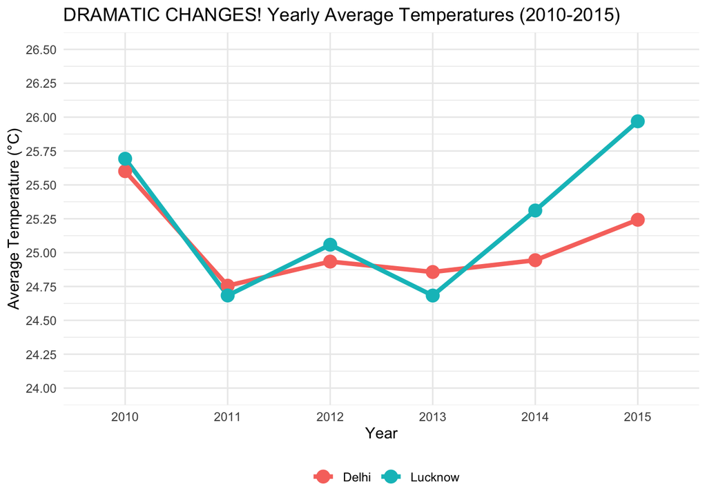

```r
# Filter data for years between 2010 and 2015, for Delhi and Lucknow, and remove NA values in tavg column
selected_data <- df[df$year >= 2010 & df$year <= 2015 & !is.na(df$tavg) & (df$city %in% c("Delhi", "Lucknow")),]

# Compute yearly average temperature for all cities
yearly_avg <- aggregate(tavg ~ year + city, data=selected_data, mean, na.rm=TRUE)

# Plot with an exaggerated y-axis
p <- ggplot(yearly_avg, aes(x=factor(year), y=tavg, color=city, group=city)) +
  geom_line(size=1.5) +
  geom_point(size=4) +
  scale_y_continuous(limits=c(24, 26.5), breaks = seq(24, 26.5, by = 0.25)) + # This restricts the y-axis
  labs(title="DRAMATIC CHANGES! Yearly Average Temperatures (2010-2015)",
       x="Year",
       y="Average Temperature (°C)") +
  theme_minimal() +
  theme(legend.position="bottom",
        legend.title=element_blank())
print(p)
```

**Graph Description:**

**This graph displays the yearly average temperatures for Delhi and Lucknow between the years 2010 and 2015. It uses lines and points to depict the temperature trends over the years for these two cities.**

**Why it’s Unethical:**

**Y-Axis Manipulation: The y-axis range from 24°C to 26.5°C exaggerates temperature differences, making them seem more dramatic than they might be.**

**Selective Data: Only data from Delhi and Lucknow from 2010 to 2015 is shown, potentially omitting broader trends.**

**Misleading Title: The title, “DRAMATIC CHANGES! Yearly Average Temperatures (2010-2015)”, uses emotive language without providing context on typical fluctuations.**

**No Error Indication: There are no error bars or confidence intervals to show data variability.**

**Ethical data visualization should be transparent and honest. This graph, however, might mislead viewers with its presentation, potentially causing misconceptions.**